# How to Predict the Sales of a Game

## A Tutorial by Ritik Chopra

The video games industry is rapidly changing. More people than ever before have subscribed to the hobby, making it one of the largest industries ever in terms of media. With this tutorial, I would like to take a closer look at what has made past games successful. Examining the impact region, publisher, genre, reviews, and even year have on how well a game performs could be paramount in predicting the success of a game within that time frame, as well as potential future ones.

```python
import pandas as pd
import matplotlib.pyplot as plt
import numpy as np
from sklearn.linear_model import LinearRegression
import seaborn as sns
import statsmodels.api as sm
import statsmodels.formula.api as smf
```

```python
data = pd.read_csv("Video Games Sales.csv", sep=',')
data.dropna()
data.head()
```

|  | index | Rank | Game Title | Platform | Year | Genre | Publisher | North America | Europe | Japan | Rest of World | Global | Review |
| --- | --- | --- | --- | --- | --- | --- | --- | --- | --- | --- | --- | --- | --- |
| 0 | 0 | 1 | Wii Sports | Wii | 2006.0 | Sports | Nintendo | 40.43 | 28.39 | 3.77 | 8.54 | 81.12 | 76.28 |
| 1 | 1 | 2 | Super Mario Bros. | NES | 1985.0 | Platform | Nintendo | 29.08 | 3.58 | 6.81 | 0.77 | 40.24 | 91.00 |
| 2 | 2 | 3 | Mario Kart Wii | Wii | 2008.0 | Racing | Nintendo | 14.50 | 12.22 | 3.63 | 3.21 | 33.55 | 82.07 |
| 3 | 3 | 4 | Wii Sports Resort | Wii | 2009.0 | Sports | Nintendo | 14.82 | 10.51 | 3.18 | 3.01 | 31.52 | 82.65 |
| 4 | 4 | 5 | Tetris | GB | 1989.0 | Puzzle | Nintendo | 23.20 | 2.26 | 4.22 | 0.58 | 30.26 | 88.00 |

## Correlations to Global Revenue

To get an idea of what correlations we can begin looking for, we can try to see if there is a correlation between global earnings and the review scores of the games.

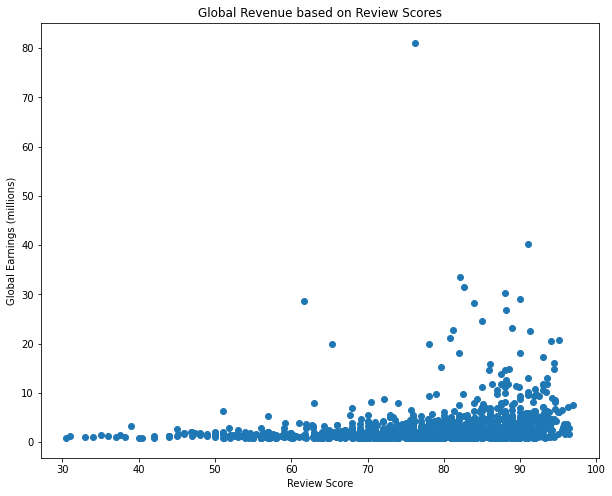

```python
# Plotting the review data against the global earnings data
fig, ax = plt.subplots(figsize=(10,8))
plt.scatter(data["Review"], data["Global"])
plt.title("Global Revenue based on Review Scores")
plt.xlabel("Review Score")
plt.ylabel("Global Earnings (millions)")
plt.show()
```

While there seems to be a small linear correlation between the score of a game and its global earnings, the majority of the change in earnings occurs when the review scores get significantly higher, as seen by the graph. To get a better idea of if a correlation exists between the two, we can take the average earnings per review interval and see if there is an increase. I used an interval of 10 since most reviewers often score in intervals of 10s (5/10, 8/10, etc.). This could affect nuances at the higher ratings, where the majority of games will likely lie. When considering a larger prediction, however, I believe these nuances are not fully necessary to the analysis.

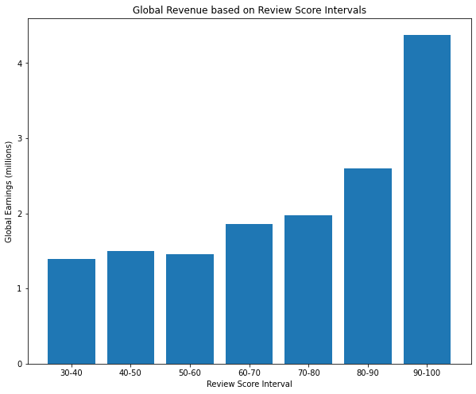

```python
# Mapping intervals directly with tuples, as well as initializing an empty array to store average values
reviewInterval = [(30,40), (40,50), (50,60), (60, 70), (70,80), (80,90), (90,100)]
reviewAverages = []

# For each ampped interval, use pandas loc method to get a column of the global earnings between
# interval 1 and 2 using the given tuple. The interval is inclusive on the lower bound, and exclusive
# on the upper bound. Take the mean of the resulting column and append it to the list of averages.
for interval in reviewInterval:
    globalEarnings = data.loc[(data["Review"] >= interval[0]) & (data["Review"] < interval[1])].Global
    averageEarnings = globalEarnings.mean()
    reviewAverages.append(averageEarnings)

reviewLabels = ["30-40", "40-50", "50-60", "60-70", "70-80", "80-90", "90-100"]
fig, ax = plt.subplots(figsize=(10,8))
plt.bar(reviewLabels, reviewAverages)
plt.title("Global Revenue based on Review Score Intervals")
plt.xlabel("Review Score Interval")
plt.ylabel("Global Earnings (millions)")
plt.show()
```

As we can see, a correlation is observable between higher review scores and higher average global earnings. What is interesting, however, is that in the lower ratings the average earnings are relatively similar. Moreover, for games that are supposedly among the top earners of the industry, the low reviews indicate that something beyond the game's content is influencing its performance. Below I take a quick examination of this theory and find that many of the games rated below 50 on average are spinoff games of another franchise. It is likely that these games found their success in the market due to their branding.

```python
worstGames = data.loc[(data["Review"] >= 30) & (data["Review"] < 40)]
worstGames.head(10)
```

|  | index | Rank | Game Title | Platform | Year | Genre | Publisher | North America | Europe | Japan | Rest of World | Global | Review |
| --- | --- | --- | --- | --- | --- | --- | --- | --- | --- | --- | --- | --- | --- |
| 335 | 335 | 336 | Baseball | NES | 1983.0 | Sports | Nintendo | 0.73 | 0.10 | 2.35 | 0.02 | 3.20 | 39.00 |
| 953 | 953 | 954 | High School Musical 3: Senior Year | DS | 2008.0 | Misc | Disney Interactive Studios | 0.60 | 0.75 | 0.00 | 0.17 | 1.53 | 35.00 |
| 959 | 959 | 960 | The Simpsons Skateboarding | PS2 | 2002.0 | Sports | Electronic Arts | 0.36 | 0.90 | 0.00 | 0.27 | 1.52 | 37.58 |
| 1209 | 1209 | 1210 | High School Musical 3: Senior Year DANCE! | Wii | 2008.0 | Misc | Disney Interactive Studios | 0.64 | 0.48 | 0.00 | 0.13 | 1.26 | 36.00 |
| 1237 | 1237 | 1238 | Jillian Michaels' Fitness Ultimatum 2009 | Wii | 2008.0 | Sports | Deep Silver | 0.94 | 0.20 | 0.00 | 0.11 | 1.24 | 31.00 |
| 1387 | 1387 | 1388 | High School Musical 2: Work This Out! | DS | 2008.0 | Misc | Disney Interactive Studios | 0.49 | 0.52 | 0.00 | 0.13 | 1.14 | 33.00 |
| 1477 | 1477 | 1478 | Dragon Ball Z: Taiketsu | GBA | 2003.0 | Fighting | Atari | 0.77 | 0.29 | 0.00 | 0.02 | 1.08 | 38.15 |
| 1558 | 1558 | 1559 | Dora the Explorer: Dora Saves the Mermaids | DS | 2007.0 | Platform | Take-Two Interactive | 0.94 | 0.00 | 0.00 | 0.08 | 1.03 | 34.00 |
| 1573 | 1573 | 1574 | Pong: The Next Level | PS | 1998.0 | Puzzle | Hasbro Interactive | 0.56 | 0.38 | 0.00 | 0.07 | 1.01 | 37.00 |
| 1763 | 1763 | 1764 | AMF Bowling Pinbusters! | Wii | 2007.0 | Sports | Bethesda Softworks | 0.83 | 0.00 | 0.00 | 0.07 | 0.90 | 30.50 |

```python
worstGames = data.loc[(data["Review"] >= 40) & (data["Review"] < 50)]
worstGames.head(10)
```

|  | index | Rank | Game Title | Platform | Year | Genre | Publisher | North America | Europe | Japan | Rest of World | Global | Review |
| --- | --- | --- | --- | --- | --- | --- | --- | --- | --- | --- | --- | --- | --- |
| 449 | 449 | 450 | Hannah Montana | DS | 2006.0 | Action | Disney Interactive Studios | 1.59 | 0.80 | 0.00 | 0.26 | 2.64 | 45.00 |
| 645 | 645 | 646 | The Sims 2: Pets | DS | 2006.0 | Simulation | Electronic Arts | 0.91 | 0.92 | 0.00 | 0.22 | 2.05 | 46.83 |
| 673 | 673 | 674 | Spyro: Enter the Dragonfly | PS2 | 2002.0 | Platform | Universal Interactive | 0.74 | 0.95 | 0.00 | 0.28 | 1.97 | 47.00 |
| 708 | 708 | 709 | Wipeout: The Game | Wii | 2009.0 | Misc | Mindscape | 1.78 | 0.00 | 0.00 | 0.15 | 1.92 | 48.00 |
| 745 | 745 | 746 | Pinball | NES | 1984.0 | Action | Nintendo | 0.80 | 0.19 | 0.83 | 0.03 | 1.85 | 46.00 |
| 752 | 752 | 753 | Game Party 2 | Wii | 2008.0 | Misc | Midway Games | 1.24 | 0.42 | 0.00 | 0.17 | 1.83 | 46.00 |
| 778 | 778 | 779 | 50 Cent: Bulletproof | PS2 | 2005.0 | Action | Vivendi Games | 0.85 | 0.76 | 0.00 | 0.16 | 1.77 | 47.38 |
| 807 | 807 | 808 | Twisted Metal III | PS | 1998.0 | Action | 989 Studios | 1.48 | 0.20 | 0.00 | 0.05 | 1.73 | 48.97 |
| 852 | 852 | 853 | Monsters, Inc. | GBA | 2001.0 | Adventure | THQ | 0.59 | 0.95 | 0.03 | 0.10 | 1.67 | 46.00 |
| 871 | 871 | 872 | Tom Clancy's Rainbow Six | PS | 1999.0 | Shooter | Red Storm Entertainment | 0.93 | 0.63 | 0.00 | 0.08 | 1.64 | 48.07 |

Next, we can examine whether there is a correlation between a game coming out in a given year and its global earnings. We employ a similar strategy from earlier, primarily to compare the averages between years to see if any correlation exists.

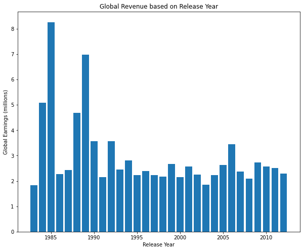

```python
# Gets every unique year value and sorts them in ascending order
# Uses the years as bins to get the averages per year based on global earnings
years = data["Year"].unique()
years = sorted(years)

# Array to store the averages per year
averagesPerYear = []

# Looping through each given year to get the global earnings column grouped by that year,
# taking the mean of the resulting column, and adding it to the averages array.
for year in years:
    globalYear = data.loc[data["Year"] == year].Global
    averageEarnings = globalYear.mean()
    averagesPerYear.append(averageEarnings)

# Plotting our findings
fig, ax = plt.subplots(figsize=(10,8))
plt.bar(years, averagesPerYear)
plt.title("Global Revenue based on Release Year")
plt.xlabel("Release Year")
plt.ylabel("Global Earnings (millions)")
plt.show()
```

As expected, there is little to no correlation between what year a game came out and its relative success. From a glance, the graph seems to indicate that games released earlier will often perform better, but this is likely due to outliers that came out in those time periods, such as Tetris in 1989. Whether those games' relative success is due to the newness of the gaming industry, because most households could only afford one or two games (and thus chose to buy the same popular game), or some other hypothesis would require much more data on games from the time period. Nevertheless, there are too many outliers and not enough of a pattern to consider this in our predictive model.

We can repeat the same analysis for performance by genre, as well as performance by publisher.

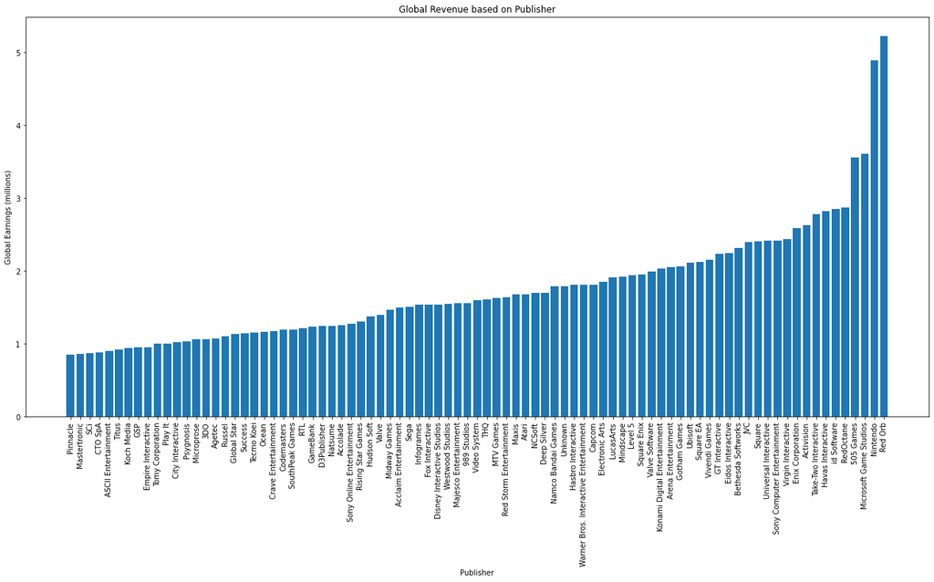

```python
# Necessary for certain publishers that are a series of numbers to cast the column to the string type
# Also sets up empty array and map to store average to label mappings and average values.
publishers = data["Publisher"].astype(str).unique()
averagesForPublishers = []
averageToPublisher = {}

# Similar to the others, go through each publisher and obtain the global revenue values for said publisher
# via the pandas loc method, obtain the average and map it to the publisher and store in an array
for publisher in publishers:
    # Drop nan publisher from analysis, it didn't get picked up because in the dataset it was read in
    # as the string "nan"
    if publisher != "nan":
        globalRevenue = data.loc[data["Publisher"] == publisher].Global
        average = globalRevenue.mean()
        averageToPublisher[average] = publisher
        averagesForPublishers.append(average)

# Sorts the list in ascending order and then creates an array to store the
# sorted label order.
averagesForPublishers = sorted(averagesForPublishers)
publisherLabels = []

# Retrieve and appends the genre per the sorted order of the averages in ascending order
for average in averagesForPublishers:
    publisherLabels.append(averageToPublisher[average])

# Creates a bar graph with rotated xlabels because there are a lot of publishers
fig, ax = plt.subplots(figsize=(22,10))
plt.bar(publisherLabels, averagesForPublishers)
plt.title("Global Revenue based on Publisher")
plt.xlabel("Publisher")
plt.ylabel("Global Earnings (millions)")
plt.xticks(rotation = 90)

plt.show()
```

There is a further correlation to be seen between the company and the global earnings of a game. High-profile companies that have been in the industry longer such as Nintendo and Activision are higher up, with lower-profile companies with less experience towards the bottom such as Pinnacle and SCI.

What's interesting to note here as well is the performance of the company Red Orb.

```python
redOrb = data.loc[data["Publisher"] == "Red Orb"]
redOrb.head()
```

|  | index | Rank | Game Title | Platform | Year | Genre | Publisher | North America | Europe | Japan | Rest of World | Global | Review |
| --- | --- | --- | --- | --- | --- | --- | --- | --- | --- | --- | --- | --- | --- |
| 67 | 67 | 68 | Myst | PC | 1994.0 | Adventure | Red Orb | 4.91 | 2.79 | 0.0 | 0.33 | 8.03 | 84.0 |
| 510 | 510 | 511 | Riven: The Sequel to Myst | PC | 1997.0 | Adventure | Red Orb | 1.52 | 0.82 | 0.0 | 0.10 | 2.43 | 84.0 |

Despite only having two games to their name, one of their games managed to skew their average so high that it competes effectively with other publishers. Because of the nature of the analysis, this is hard to combat. Nintendo as a company has made many more games and maintains the second-highest average among them all, but to weigh Nintendo as higher than a company with fewer games creates the problem of companies that have simply been in the industry longer. For the purposes of the prediction, assuming a game that comes out of Red Orb will be good is a fair assumption.

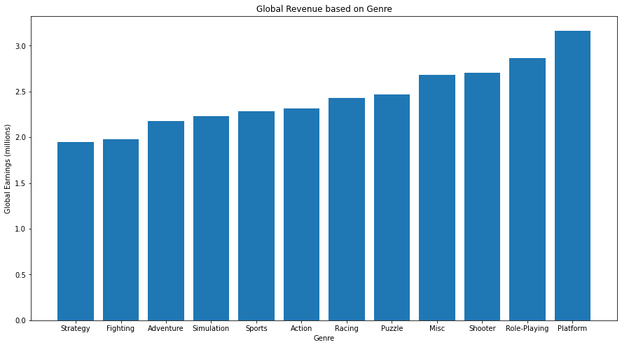

```python
# Gets every unique genre in the data, sets an empty array to store the averages,
# and a dictionary to map each genre to its average, so that we can plot in ascending order
genres = data["Genre"].unique()
averagesForGenres = []
averageToGenre = {}

# Goes through each genre, taking the global revenue data from the data using
# pandas' loc method, then takes the average over the resulting column,
# maps the average value to the current genre in the loop, and finally
# appends the average to the list.
for genre in genres:
    globalRevenue = data.loc[data["Genre"] == genre].Global
    average = globalRevenue.mean()
    averageToGenre[average] = genre
    averagesForGenres.append(average)

# Sorts the list in ascending order and then creates an array to store the
# sorted label order.
averagesForGenres = sorted(averagesForGenres)
genreLabels = []

# Retrieve and appends the genre per the sorted order of the averages in ascending order
for average in averagesForGenres:
    genreLabels.append(averageToGenre[average])

# Plots a bar graph
fig, ax = plt.subplots(figsize=(15,8))
plt.bar(genreLabels, averagesForGenres)
plt.title("Global Revenue based on Genre")
plt.xlabel("Genre")
plt.ylabel("Global Earnings (millions)")
plt.show()
```

We can see from the graph that there is a correlation between genre and average global earnings. Platformers, role-playing games, and shooters lead the pack, which intuitively makes sense as RPGs and Platformers are known to be a wide appeal for both younger and older audiences in terms of both content and difficulty. Shooters usually aim toward an older audience, and this was especially true in 2012. What is also true is that it is not very difficult to obtain an M-rated game as someone below the age of 18, as it simply required a guardian above the age of 18 to sign off on the game. Strategy, fighting, and adventure games lead to the bottom of the genre list. Strategy and fighting are both very niche genres, which correlates to them being lower earners overall. Adventure games often end up in the role-playing category, so the mismatch of their wide appeal to their earnings could be explained by this.

The general trend seems to be that genres with wide appeals are the ones most likely to do better, but the misc. the genre seems to combat this, being the genre with the 4th highest average earnings across the years.

```python
misc = data.loc[data["Genre"] == "Misc"]
misc.head(15)
```

|  | index | Rank | Game Title | Platform | Year | Genre | Publisher | North America | Europe | Japan | Rest of World | Global | Review |
| --- | --- | --- | --- | --- | --- | --- | --- | --- | --- | --- | --- | --- | --- |
| 6 | 6 | 7 | Wii Play | Wii | 2006.0 | Misc | Nintendo | 13.83 | 9.11 | 2.93 | 2.84 | 28.71 | 61.64 |
| 16 | 16 | 17 | Brain Age: Train Your Brain in Minutes a Day | DS | 2005.0 | Misc | Nintendo | 4.72 | 9.10 | 4.16 | 2.04 | 20.02 | 78.05 |
| 17 | 17 | 18 | Kinect Adventures! | X360 | 2010.0 | Misc | Microsoft Game Studios | 13.50 | 4.34 | 0.24 | 1.82 | 19.90 | 65.39 |
| 23 | 23 | 24 | Brain Age 2: More Training in Minutes a Day | DS | 2005.0 | Misc | Nintendo | 3.41 | 5.32 | 5.32 | 1.18 | 15.24 | 79.61 |
| 51 | 51 | 52 | Just Dance 3 | Wii | 2011.0 | Misc | Ubisoft | 5.63 | 3.17 | 0.00 | 0.98 | 9.78 | 79.00 |
| 55 | 55 | 56 | Just Dance 2 | Wii | 2010.0 | Misc | Ubisoft | 5.68 | 2.78 | 0.01 | 0.91 | 9.39 | 78.00 |
| 61 | 61 | 62 | Mario Party DS | DS | 2007.0 | Misc | Nintendo | 4.27 | 1.75 | 1.98 | 0.70 | 8.69 | 72.17 |
| 64 | 64 | 65 | Wii Party | Wii | 2010.0 | Misc | Nintendo | 1.68 | 3.28 | 2.46 | 0.67 | 8.09 | 70.44 |
| 69 | 69 | 70 | Mario Party 8 | Wii | 2007.0 | Misc | Nintendo | 3.68 | 1.95 | 1.58 | 0.68 | 7.90 | 63.04 |
| 82 | 82 | 83 | Just Dance | Wii | 2009.0 | Misc | Ubisoft | 3.32 | 2.90 | 0.00 | 0.74 | 6.96 | 68.00 |
| 90 | 90 | 91 | Big Brain Academy | DS | 2005.0 | Misc | Nintendo | 1.65 | 2.70 | 1.60 | 0.61 | 6.56 | 75.73 |
| 136 | 136 | 137 | Just Dance 4 | Wii | 2012.0 | Misc | Ubisoft | 3.03 | 1.78 | 0.00 | 0.51 | 5.32 | 57.00 |
| 137 | 137 | 138 | Pokémon Pinball | GB | 1999.0 | Misc | Nintendo | 3.02 | 1.12 | 1.01 | 0.16 | 5.31 | 80.00 |
| 152 | 152 | 153 | Guitar Hero II | PS2 | 2006.0 | Misc | RedOctane | 3.81 | 0.63 | 0.00 | 0.68 | 5.12 | 90.00 |
| 163 | 163 | 164 | Guitar Hero III: Legends of Rock | PS2 | 2007.0 | Misc | Activision | 3.49 | 1.05 | 0.01 | 0.43 | 4.98 | 86.00 |

Looking at the top 15 games in the misc. genre, we can see that there is a focus on slightly more innovative design. Kinect adventures utilized completely different technologies, guitar hero was a leading title in the rhythm game subgenre, and Pokemon Pinball was a drastically different type of game than the traditional Pokemon series. The publishers present here are all some of the top earners, which could very well be a confounding variable in this analysis. While adhering to the most common genres is effective, there is seemingly a benefit to being more innovative with your game's design.

Finally, we can take a look at the average global revenues per country (not every location given is a country, but I opted to refer to them as such).

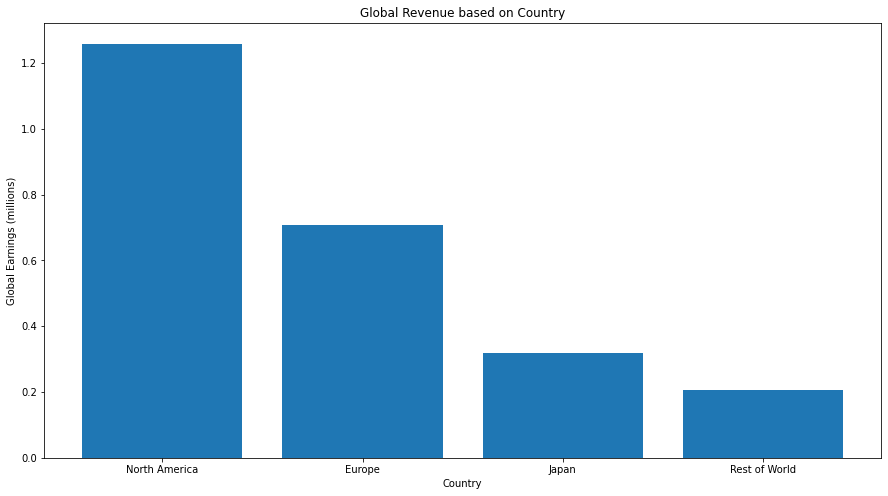

```python
# Gets the means for each country column
averageNA = data["North America"].mean()
averageEuro = data["Europe"].mean()
averageJP = data["Japan"].mean()
averageOther = data["Rest of World"].mean()

# Appends each average to a list
averages = []
averages.append(averageNA)
averages.append(averageEuro)
averages.append(averageJP)
averages.append(averageOther)

countries = ["North America", "Europe", "Japan", "Rest of World"]

# Plots a bar graph
fig, ax = plt.subplots(figsize=(15,8))
plt.bar(countries, averages)
plt.title("Global Revenue based on Country")
plt.xlabel("Country")
plt.ylabel("Global Earnings (millions)")
plt.show()
```

North America has nearly double the average global revenue in comparison to Europe, making it the predominant frontrunner for the gaming industry's revenue. There is a correlation between which country a game is created in and its revenue in that country, which feels obvious. However, there may be some nuances as to which games are more likely to succeed depending on location.

## Hypothesis Testing with Top Earning Games in Different Countries

To see if games of a certain genre are more likely to succeed depending on their location, I employed an ANOVA test to see if a correlation exists for each location given in the dataset.

```python
import scipy.stats as stats

# Using scipy's f_oneway method we can perform an ANOVA test across all genres for each country
# using this function. The function takes each group (genre) and its samples (in this case the revenue of
# the given game in the genre in that country) to perform an ANOVA test.
def anovaGenre(country):
    results = stats.f_oneway(data[country][data['Genre'] == 'Sports'],
                   data[country][data['Genre'] == 'Platform'],
                   data[country][data['Genre'] == 'Racing'],
                   data[country][data['Genre'] == 'Puzzle'],
                   data[country][data['Genre'] == 'Misc'],
                   data[country][data['Genre'] == 'Shooter'],
                   data[country][data['Genre'] == 'Simulation'],
                   data[country][data['Genre'] == 'Role-Playing'],
                   data[country][data['Genre'] == 'Action'],
                   data[country][data['Genre'] == 'Fighting'],
                   data[country][data['Genre'] == 'Adventure'],
                   data[country][data['Genre'] == 'Strategy'])
    return results
```

```python
print("ANOVA Test for North America: ", anovaGenre("North America"))
print("ANOVA Test for Europe: ", anovaGenre("Europe"))
print("ANOVA Test for Japan: ", anovaGenre("Japan"))
print("ANOVA Test for Others: ", anovaGenre("Rest of World"))
```

```
ANOVA Test for North America:  F_onewayResult(statistic=2.019739379539032, pvalue=0.023308757348584425)
ANOVA Test for Europe:  F_onewayResult(statistic=1.3601968867637597, pvalue=0.1853179855924563)
ANOVA Test for Japan:  F_onewayResult(statistic=22.55522135382596, pvalue=7.146323824698905e-44)
ANOVA Test for Others:  F_onewayResult(statistic=2.740746807305037, pvalue=0.0015950537515354798)
```

The tests indicate that there is a correlation between genre and earnings in every country except Europe, as its p-value is not less than 0.05. In contrast, Japan seems to have very strong evidence against the null hypothesis, meaning a certain genre is seemingly very profitable in Japan. Let's visualize this with a grouped bar plot.

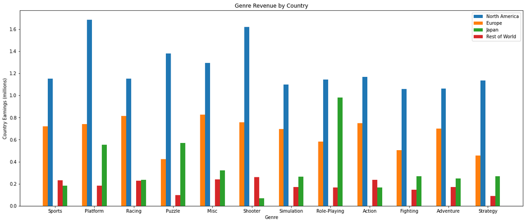

```python
# Formulates plot and sets width for bar plot
fig, ax = plt.subplots(figsize=(20,8))
width = 0.5

# Set dictionary with empty array values per location to initialize space for the average values
vals = {}
vals["North America"] = []
vals["Europe"] = []
vals["Japan"] = []
vals["Rest of World"] = []

# Group by genre, using a numerical interval for the grouped bar plot
groups = np.arange(len(genres))

# For each location, go through each genre and append the average to that
# location's list of averages
for country in countries:
    for genre in genres:
        average = data.loc[(data["Genre"] == genre)][country].mean()
        vals[country].append(average)

# plots each bar at the index of the grouping values generated
# segmented by the chosen width value
plt.bar(groups - width/4, vals["North America"], width=width/4)
plt.bar(groups - width/2, vals["Europe"], width=width/4)
plt.bar(groups + width/2, vals["Japan"], width=width/4)
plt.bar(groups + width/4, vals["Rest of World"], width=width/4)

# Plots the grouped bar plot
plt.title("Genre Revenue by Country")
plt.xlabel("Genre")
ax.set_xticks(groups, genres)
plt.ylabel("Country Earnings (millions)")
plt.legend(countries)
plt.show()
```

## Using a Regressive Random Forest to Predict Earnings

Finally, we can use the correlations we've deduced to form a random forest regressor model that is capable of predicting the earnings of a game based on given features. Because we have a set of categorical variables alongside a numerical review feature, one hot encoding is necessary to ensure that categories are properly represented in the model. The features I chose were Genre, Publisher, and Review score

```python
from sklearn.model_selection import train_test_split
from sklearn.tree import DecisionTreeRegressor
from sklearn.ensemble import RandomForestRegressor

# Pandas' get dummies method allows us to generate extra columns based on categorical data
# and then one-hot encodes based on whether that entry has the category represented
# Then train test splits the chosen categories
hotEncoded = pd.get_dummies(data[["Genre", "Publisher", "Review"]], drop_first=True)
X_train, X_test, Y_train, Y_test = train_test_split(hotEncoded, data["Global"])

# Uses sklearn random forest regressor with 100 estimators to settle on the best fitting tree,
# fits on regressor using fit method of the pandas' tree module, and finally evaluates the
# score of the regression model using the score method form pandas as well
regressor = RandomForestRegressor(n_estimators = 100, random_state = 0)
regressor = regressor.fit(X_train, Y_train)
score = regressor.score(X_train, Y_train)
print("Score on training: ", score)
```

```
Score on training:  0.7529124779715323
```

```python
from sklearn.tree import DecisionTreeClassifier
from sklearn.metrics import accuracy_score
from sklearn.metrics import mean_squared_error

# Uses the pandas predict method to predict on the test set, and then calculates the
# mean squared error, and the root mean squared error of the model. Score could not
# be calculated because the accurcay score method is not supported for continuous
# results
predictions = regressor.predict(X_test)
mse = mean_squared_error(Y_test, predictions)

print("Mean Squared Error: ", mse)
print("RMSE: ", mse**(1/2.0))
```

```
Mean Squared Error:  10.028246737693777
RMSE:  3.166740712103499
```

The model shows fairly decent accuracy with the training set, but the RMSE is very high on the test set which indicates its ability to predict is subpar. The need for further features is apparent, as while the ones given have a clear relation to the global earnings of a game, predicting the earnings of a game globally seems to be influenced by too many factors for them to fully weigh in on an accurate prediction. There is potential for predicting the earnings of a game in the given locations.

```python
# Employs the exact same methodology as the global entries, except it uses the revenue from North America only
X_train, X_test, Y_train, Y_test = train_test_split(hotEncoded, data["North America"])

regressor = RandomForestRegressor(n_estimators = 100, random_state = 0)
regressor = regressor.fit(X_train, Y_train)
score = regressor.score(X_train, Y_train)
print("Score on training: ", score)

predictions = regressor.predict(X_test)
mse = mean_squared_error(Y_test, predictions)

print("Mean Squared Error: ", mse)
print("RMSE: ", mse**(1/2.0))
```

```
Score on training:  0.8052282849869004
Mean Squared Error:  5.063618182243436
RMSE:  2.2502484712234416
```

```python
# Employs the exact same methodology as the global entries, except it uses the revenue from Europe only
X_train, X_test, Y_train, Y_test = train_test_split(hotEncoded, data["Europe"])

regressor = RandomForestRegressor(n_estimators = 100, random_state = 0)
regressor = regressor.fit(X_train, Y_train)
score = regressor.score(X_train, Y_train)
print("Score on training: ", score)

predictions = regressor.predict(X_test)
mse = mean_squared_error(Y_test, predictions)

print("Mean Squared Error: ", mse)
print("RMSE: ", mse**(1/2.0))
```

```
Score on training:  0.7597569181793913
Mean Squared Error:  3.0469683941608188
RMSE:  1.7455567576451987
```

```python
# Employs the exact same methodology as the global entries, except it uses the revenue from Japan only
X_train, X_test, Y_train, Y_test = train_test_split(hotEncoded, data["Japan"])

regressor = RandomForestRegressor(n_estimators = 100, random_state = 0)
regressor = regressor.fit(X_train, Y_train)
score = regressor.score(X_train, Y_train)
print("Score on training: ", score)

predictions = regressor.predict(X_test)
mse = mean_squared_error(Y_test, predictions)

print("Mean Squared Error: ", mse)
print("RMSE: ", mse**(1/2.0))
```

```
Score on training:  0.834934598884773
Mean Squared Error:  0.47058467308873414
RMSE:  0.685991744184093
```

```python
# Employs the exact same methodology as the global entries, except it uses the revenue from other locations only
X_train, X_test, Y_train, Y_test = train_test_split(hotEncoded, data["Rest of World"])

regressor = RandomForestRegressor(n_estimators = 100, random_state = 0)
regressor = regressor.fit(X_train, Y_train)
score = regressor.score(X_train, Y_train)
print("Score on training: ", score)

predictions = regressor.predict(X_test)
mse = mean_squared_error(Y_test, predictions)

print("Mean Squared Error: ", mse)
print("RMSE: ", mse**(1/2.0))
```

```
Score on training:  0.7573542564089868
Mean Squared Error:  0.18263453659142267
RMSE:  0.42735762142662514
```

## Conclusion

After examining relationships between the data of the top 2000 games of 2012 (roughly), we were able to extrapolate correlative variables to then hypothesis test on and add to our model which could predict (with questionable accuracy) the earnings of the game based on its genre, publisher, and review score.

This data analysis helps to understand the culture of gaming during this time period, and perhaps can give insight into the culture of its future.

## Resources

I made use of geeks for geeks a lot when making my model, so if you're curious about designing your own random forest, see the link: https://www.geeksforgeeks.org/random-forest-regression-in-python/

If you are looking to perform your own hypothesis testing, I suggest the link here https://www.statsmodels.org/dev/stats.html. The documentation for statmodels is good to start with if you are more programmatically inclined.

Finally, I found this article https://www.marsja.se/four-ways-to-conduct-one-way-anovas-using-python/, to be very helpful in properly conducting my ANOVA test for my data.